# Using Regression Splines and Knots to Model Ozone Data

Samuel Greeman

2021-03-30

```r
rm(list = ls())
library("splines")
ozone.data <- read.table("https://web.stanford.edu/~hastie/ElemStatLearn/datasets/ozone.data", header=TRUE)
```

Here, all we are doing is loading the package “splines” which has many functions that will be useful when creating our models.

## Part A

```r
get.knots <- function(x, basis.knots=c(0.25, 0.5, 0.75)){
  return(quantile(x, probs=basis.knots))
}
```

This function will generate knots based on our input at the 25th percentile, 50th percentile, and 75th percentile of the data.

```r
get.basis <- function(x, knots, intercept.index = FALSE){
  basis <- t(apply(matrix(x, ncol=1), 1, function(x){(x - knots)*((x - knots)>0)}))
  basis <- cbind(x, x^2, x^3, basis^3)
  if(intercept.index){
    basis <- cbind(1, basis)
  }
  return(basis)
}
```

The basis function will get the a basis for our data based on our knots, and it will be made up of polynomials in the 1st, 2nd and 3rd degree, as well as cubic splines generated at the knots we created in the previous part. We have the intercept vector of 1’s not included since it causes the predictors in our basis functions to be linear combinations of each other. By removing the vector of 1’s, we try to eliminate linear dependence.

```r
get.range <- function(x){
  return(seq(min(x), max(x), 1))
}
```

This is simply a simulation of data that range from the minimum value of our parameters to the maximum value.

```r
reg.splines <- function(x, y_in, name){
  data <- data.frame(y=y_in, x=get.basis(x, knots=get.knots(x)))
  x.new <- data.frame(x=get.basis(get.range(x), knots=get.knots(x)))
  b.model <- lm(y ~ ., data=data)
  y_hat <- predict(b.model, newdata=x.new, interval="predict")
  plot(x, y, xlab=name, ylab="Ozone", main="Regression Splines")
  lines(get.range(x), y_hat[,1], lwd=2)
  lines(get.range(x), y_hat[,2], lty=2)
  lines(get.range(x), y_hat[,3], lty=2)
  legend("topleft", legend=c("Fitted Value", "Prediction Interval"), lwd=c(2,1), lty=c(1, 2))
}
```

Now that we have created our functions for getting knots and a basis from the knots, we can create the splines. This function will start by taking x and y_in where y_in is the ozone value in the dataset and x will be the bases formed from the knots created by our get.knots function. The new.x corresponds to our get.range function that effectively simulates data from a given parameter, and this will be used when we are doing predictive analysis. Our basis.model is just a standard linear regression model with y being predicted by the given parameters. To make our prediction interval, we generate a new vector that holds predicted values, y_predicted. We use the simulated data from new.x and use our basis.model to predict the ozone values. The last 3 lines of code will generate a plot of the data with error bars.

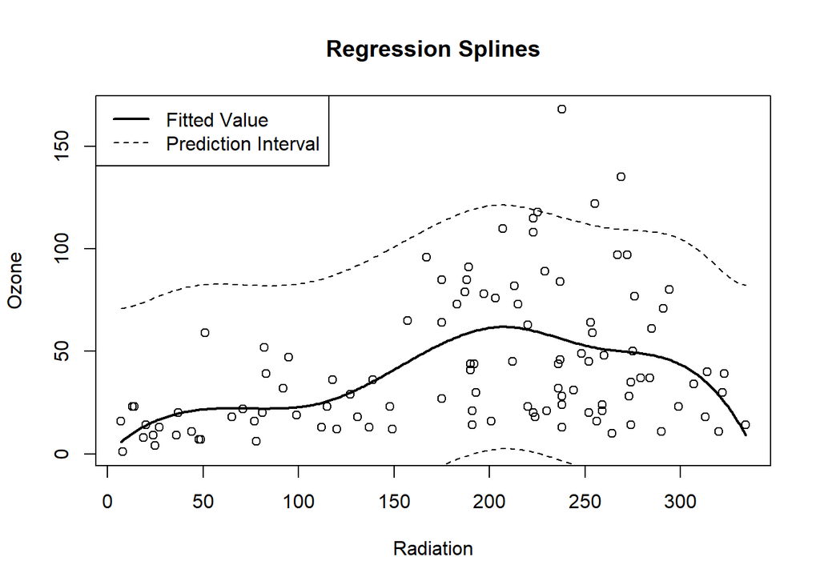

```r
y <- ozone.data$ozone
reg.splines(ozone.data$radiation, y, "Radiation")
```

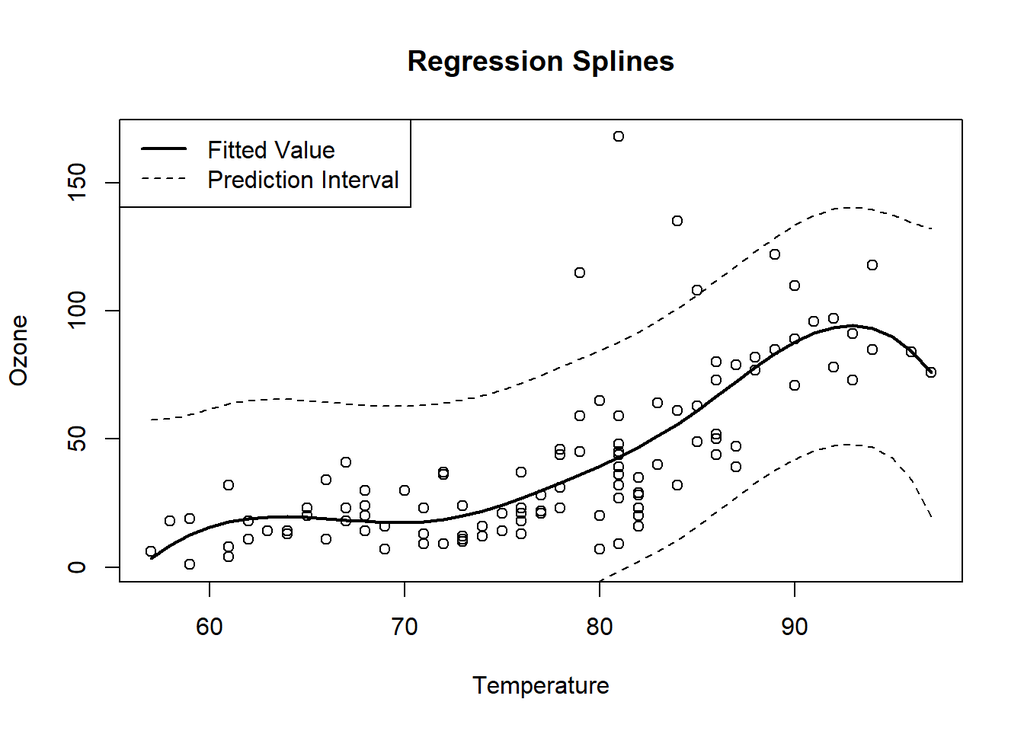

```r
reg.splines(ozone.data$temperature, y, "Temperature")
```

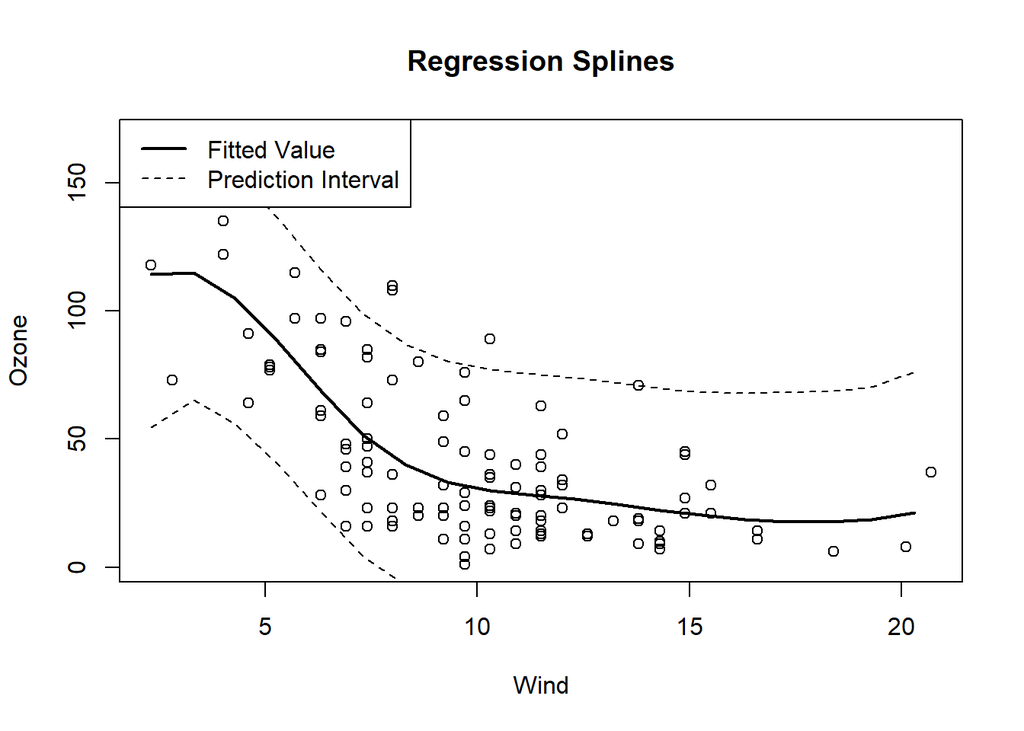

```r
reg.splines(ozone.data$wind, y, "Wind")
```

Here are the plots for each variable individually. Notice how the lines become unstable toward minimum and maximum x values, something we hope to remedy in part b and c. However, next we will combine all of our variables into the same model

```r
b.model <- lm(ozone ~ get.basis(radiation, knots=get.knots(radiation)) + get.basis(temperature, knots=get.knots(temperature)) + get.basis(wind, knots=get.knots(wind)), data=ozone.data)
y_hat <- predict(b.model)
```

To give a better idea of how well our model works, we make a model with all three variables to predict ozone. We also generate a prediction vector to see how well the model performs, and we can see the results in the plots below.

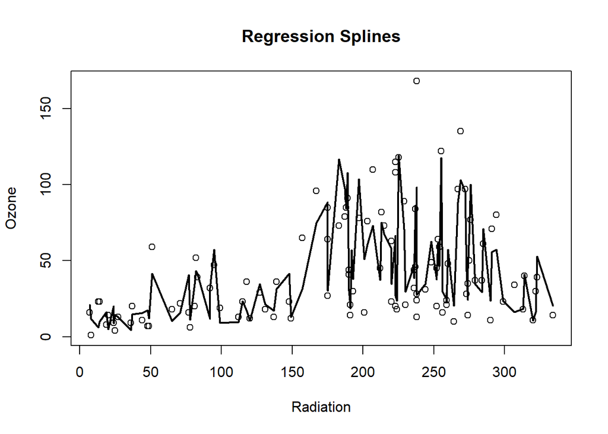

```r
reg.plot <- function(x, y, name){
  y.order <- order(x)
  plot(x[y.order], y[y.order], xlab=name, ylab="Ozone", main="Regression Splines")
  lines(x[y.order], y_hat[y.order], lwd=2)
}
reg.plot(ozone.data$radiation, y, "Radiation")
```

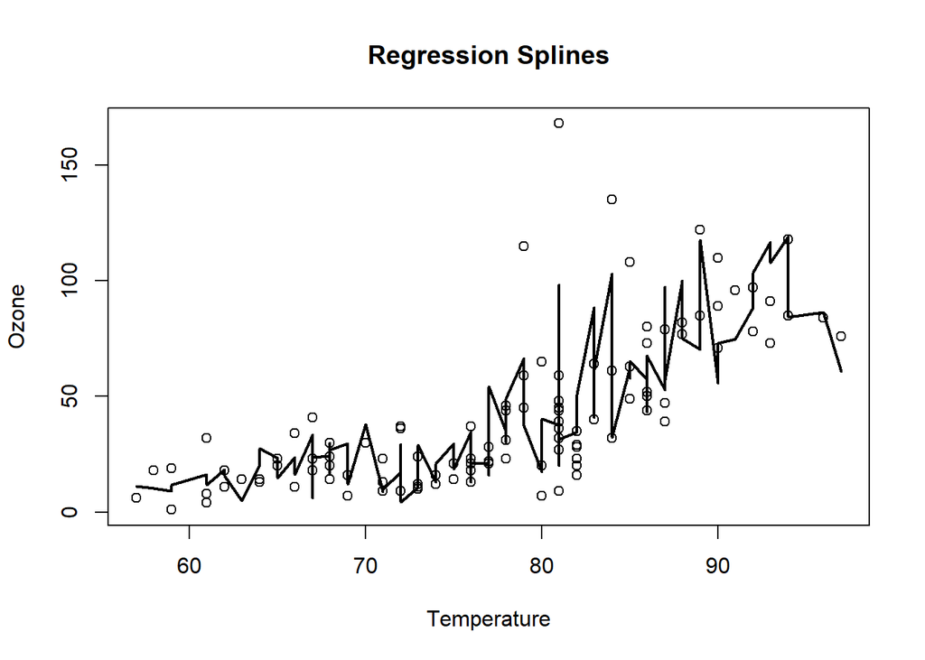

```r
reg.plot(ozone.data$temperature, y, "Temperature")
```

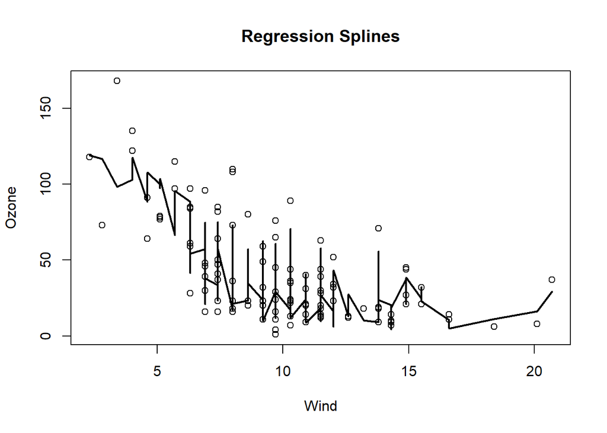

```r
reg.plot(ozone.data$wind, y, "Wind")
```

All 3 plots look relatively acceptable, as the only real problems that we can see are due to extreme outliers. The graph plots the actual values of the data, with the lines corresponding to the predicted values for a given value of the variable. As a sidenote, we would have gotten very similar results if we used the “bs” function to create our basis, which is for “B-splines”. B-splines are nearly identical in practice to normal regression splines, except the calculations are slightly different in the way they deal with larger orders of computation. Still, our plots would look the same and have the same shape.

## Part B

```r
nat.splines <- function(x, y_in, name){
  data <- data.frame(y=y_in, x=ns(x, knots=get.knots(x)))
  x.new <- data.frame(x=ns(get.range(x), knots=get.knots(x)))
  b.model <- lm(y ~ ., data=data)
  y_hat <- predict(b.model, newdata=x.new, interval="predict")
  plot(x, y, xlab=name, ylab="Ozone", main="Natural Splines")
  lines(get.range(x), y_hat[,1], lwd=2)
  lines(get.range(x), y_hat[,2], lty=2)
  lines(get.range(x), y_hat[,3], lty=2)
  legend("topleft", legend=c("Fitted Value", "Prediction Interval"), lwd=c(2,1), lty=c(1, 2))
}
```

The code/input and process are relatively similar to part a, but with some key changes. Natural splines try to eliminate erratic behavior at boundaries by removing the knots past the boundary (and defining the model outside the boundaries as linear) in order to become more precise within the boundary, by adding more knots. Here, however, we still have the same 3 fixed knots. You will notice that instead of “get.basis”, we now use “ns” to get the basis for a natural spline. This is due to the fact that natural splines are created and calculated differently, mainly in the ways I described. Below are the individual plots for for the variables using the natural splines:

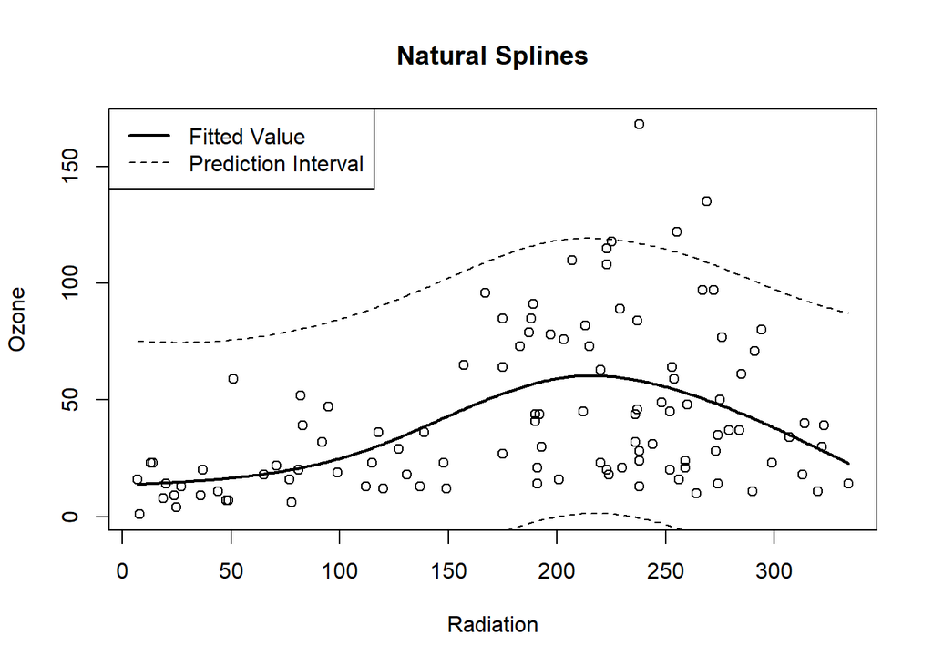

```r
nat.splines(ozone.data$radiation, y, "Radiation")
```

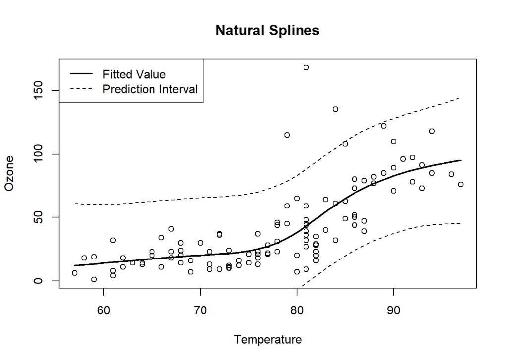

```r
nat.splines(ozone.data$temperature, y, "Temperature")
```

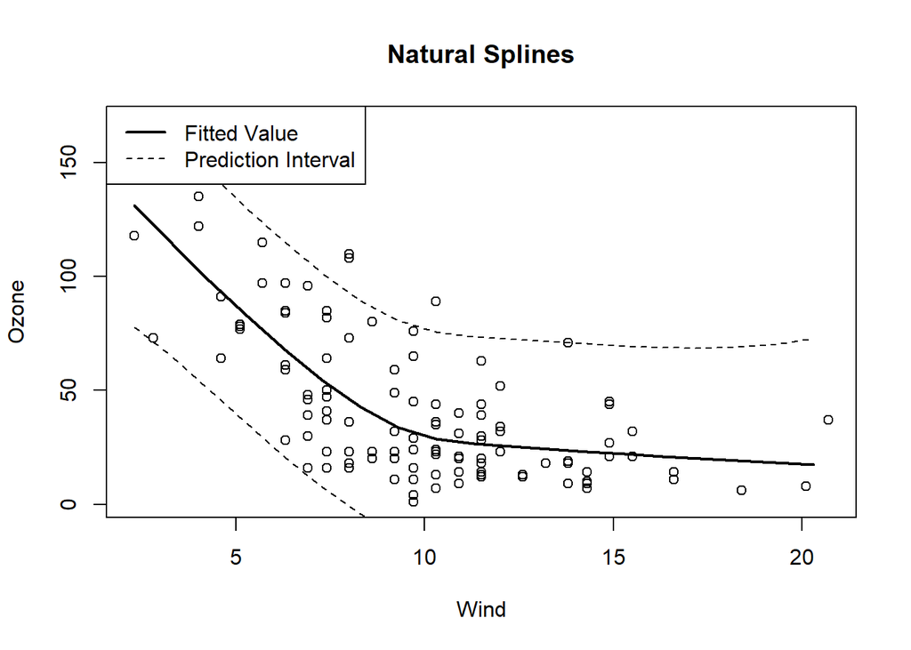

```r
nat.splines(ozone.data$wind, y, "Wind")
```

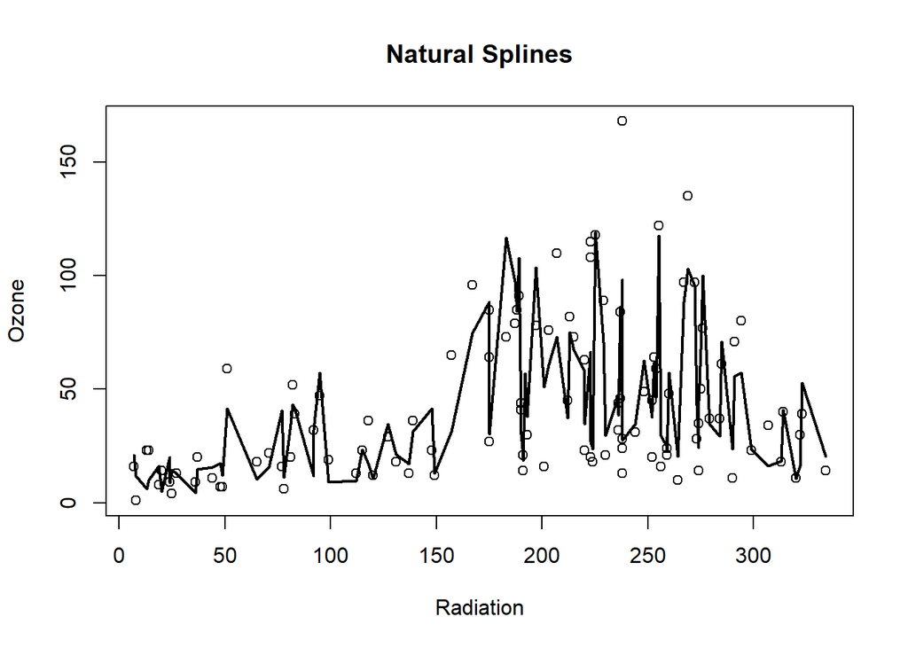

```r
natural.model <- lm(ozone ~ ns(radiation, knots=get.knots(radiation)) + ns(temperature, knots=get.knots(temperature)) + ns(wind, knots=get.knots(wind)), data=ozone.data)
y_predicted <- predict(natural.model)

nat.plot <- function(x, y, name){
  y.order <- order(x)
  plot(x[y.order], y[y.order], xlab=name, ylab="Ozone", main="Natural Splines")
  lines(x[y.order], y_hat[y.order], lwd=2)
}

nat.plot(ozone.data$radiation, y, "Radiation")
```

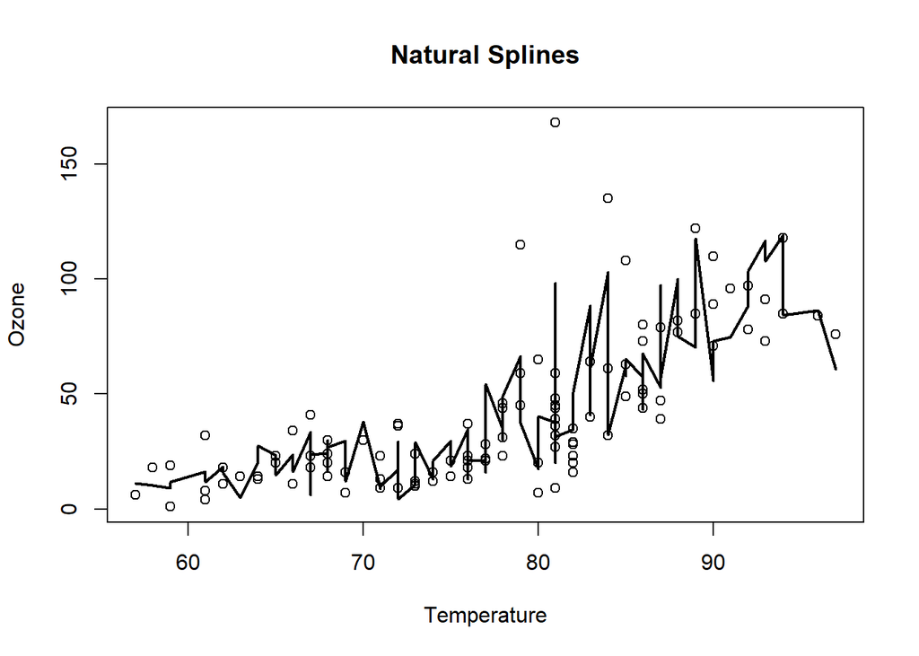

```r
nat.plot(ozone.data$temperature, y, "Temperature")
```

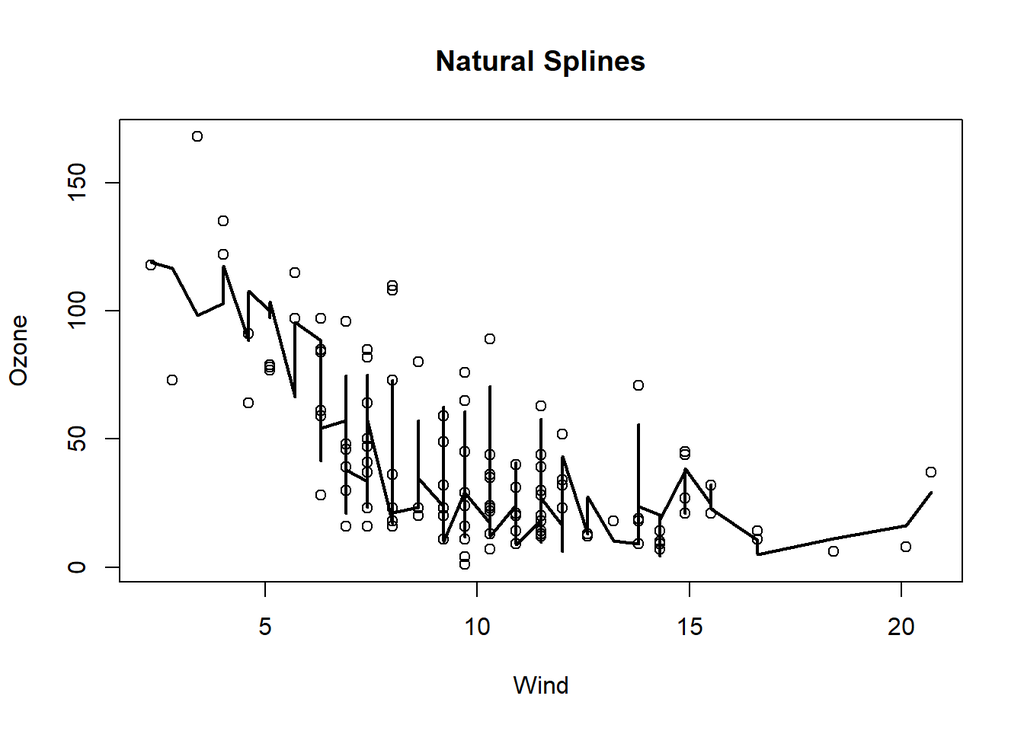

```r
nat.plot(ozone.data$wind, y, "Wind")
```

## Part C

For smoothing splines, we need only look at the individual plots for each variable to show how they work. Smoothing splines mimic natural splines except they have knots at each individual data point instead of the fixed knots as we have been doing previously. In addition, smoothing splines are generated the same way that natural splines are with a regularization or “smoothing term” lambda that is determined by the shape of the data. R has a function “smooth.spline” that makes our job easier, and as we look at the plots, we see that the smoothing splines model does a great job smoothing out the spikes in the middle of the data.

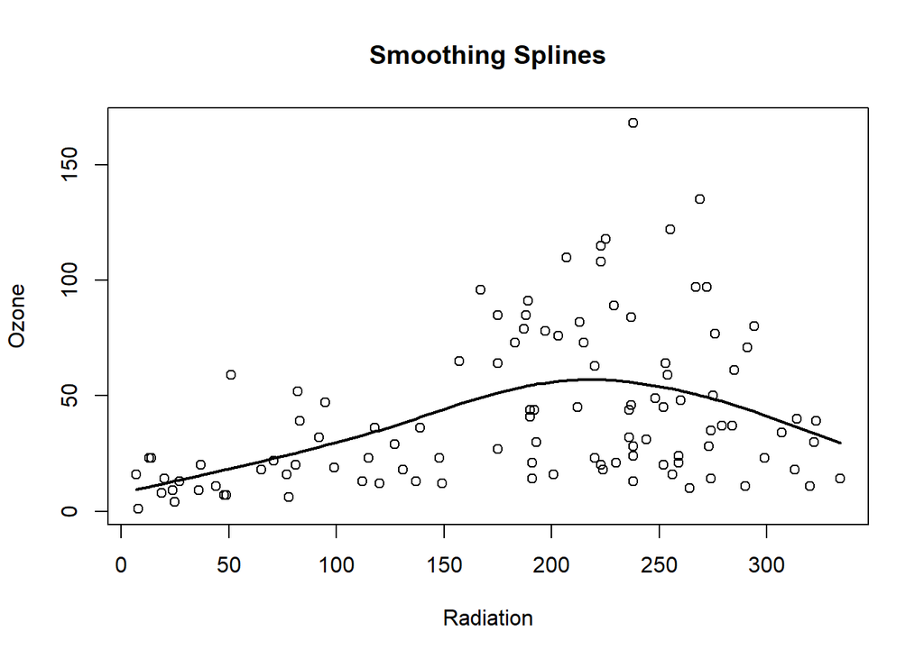

```r
smooth.plot <- function(x, y, name){
  plot(x, y, xlab=name, ylab="Ozone", main="Smoothing Splines")
  lines(smooth.spline(x, y), lwd=2)
}

smooth.plot(ozone.data$radiation, y, "Radiation")
```

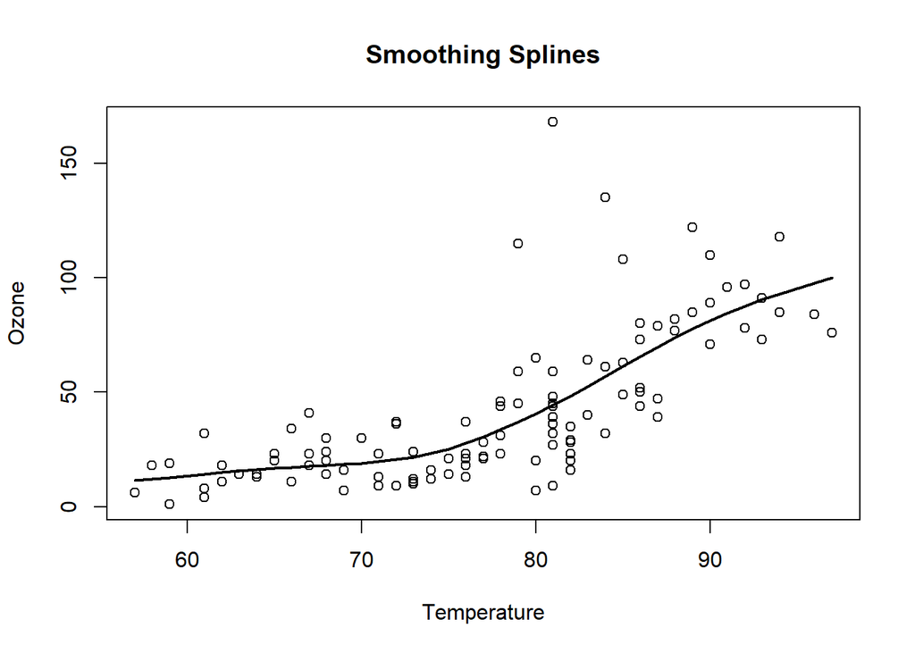

```r
smooth.plot(ozone.data$temperature, y, "Temperature")
```

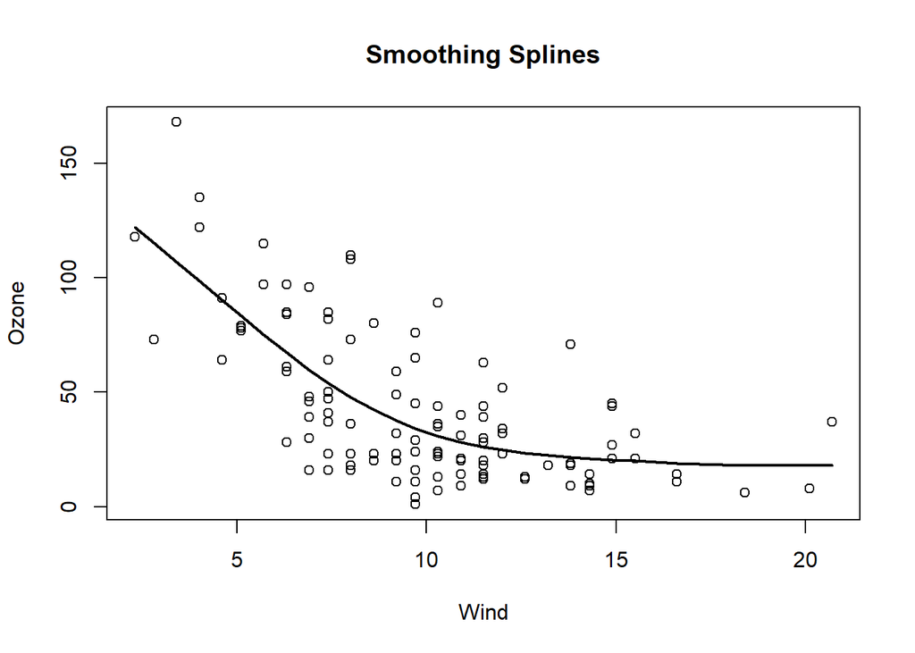

```r
smooth.plot(ozone.data$wind, y, "Wind")
```